# Virat Kohali Centuries (75)

[figure not shown]

Virat Kohli, the Indian cricket sensation, has achieved a remarkable feat by scoring 75 centuries in international cricket. Known for his exceptional batting skills and unwavering determination, Kohli has left an indelible mark on the cricketing world.

With his aggressive yet calculated approach, Kohli has consistently displayed a hunger for runs and an ability to dominate the opposition. His centuries have come across all formats of the game, including Test matches, One Day Internationals (ODIs), and Twenty20 Internationals (T20Is).

Kohli's century tally is a testament to his consistency and adaptability across different conditions and against various opponents. He has a knack for rising to the occasion in crucial matches and has been a key contributor to India's success on numerous occasions.

Beyond the sheer number of centuries, Kohli's innings have often been a masterclass in batting technique and shot selection. He combines classic stroke play with modern aggression, making him a complete batsman in every sense.

Kohli's records and achievements go beyond the number of centuries. He has amassed numerous accolades and has consistently been ranked among the top batsmen in the world. His passion for the game, coupled with his relentless pursuit of excellence, has made him an inspiration for aspiring cricketers worldwide.

In summary, Virat Kohli's 75 centuries stand as a testament to his exceptional talent, consistency, and dedication to the sport. His achievements have etched his name among the all-time greats of the game and have made him a source of pride for his country, India.

# Importing important Liabraries for analysis and visualisations

```python
import pandas as pd
import numpy as np
import seaborn as sns
import matplotlib.pyplot as plt
```

# File path

```python
file = r'd:\rg67266\Downloads\Virat-Kohli-International-Cricket-Centuries.csv'
```

# Read the CSV Datasets

```python
df = pd.read_csv(file)
```

```python
df
```

|  | No. | Runs | Against | Position | Innings | Venue | Ground | Date | Result |
| --- | --- | --- | --- | --- | --- | --- | --- | --- | --- |
| 0 | 1 | 107 | Sri Lanka | 4 | 2 | Eden Gardens, Kolkata | Home | 24-Dec-09 | Won |
| 1 | 2 | 102* | Bangladesh | 3 | 2 | Sher-e-Bangla Cricket Stadium, Dhaka | Away | 11-Jan-10 | Won |
| 2 | 3 | 118 | Australia | 3 | 2 | APCA-VDCA Stadium, Visakhapatnam | Home | 20-Oct-10 | Won |
| 3 | 4 | 105 | New Zealand | 3 | 1 | Nehru Stadium, Guwahati | Home | 28-Nov-10 | Won |
| 4 | 5 | 100* | Bangladesh | 4 | 1 | Sher-e-Bangla Cricket Stadium, Dhaka | Away | 19-Feb-11 | Won |
| ... | ... | ... | ... | ... | ... | ... | ... | ... | ... |
| 70 | 71 | 122* | Afghanistan | 2 | 1 | Dubai International Cricket Stadium, Dubai | Neutral | 08-Sep-22 | Won |
| 71 | 72 | 113 | Bangladesh | 3 | 1 | Zohur Ahmed Chowdhury Stadium, Chittagong | Away | 10-Dec-22 | Won |
| 72 | 73 | 113 | Sri Lanka | 3 | 1 | ACA Stadium, Guwahati | Home | 10-Jan-23 | Won |
| 73 | 74 | 166* | Sri Lanka | 3 | 1 | Greenfield International Stadium, Thiruvananth... | Home | 15-Jan-23 | Won |
| 74 | 75 | 186 | Australia | 4 | 2 | Narendra Modi Stadium, Ahmedabad | Home | 09-Mar-23 | Drawn |

75 rows × 9 columns

# Check the columns and rows

```python
df.shape
```

```
(75, 9)
```

# Columns

```python
df.columns
```

```
Index(['No.', 'Runs', 'Against', 'Position', 'Innings', 'Venue', 'Ground',
       'Date', 'Result'],
      dtype='object')
```

# Renaming the Columns

```python
df = df.rename(columns={
    'No.' : "Century No"
})
```

```python
df.columns
```

```
Index(['Century No', 'Runs', 'Against', 'Position', 'Innings', 'Venue',
       'Ground', 'Date', 'Result'],
      dtype='object')
```

# Checking the null columns or rows

```python
df.isnull().sum()
```

```
Century No    0
Runs          0
Against       0
Position      0
Innings       0
Venue         0
Ground        0
Date          0
Result        0
dtype: int64
```

```python
missing_values = df.isnull()
missing_values
```

|  | Century No | Runs | Against | Position | Innings | Venue | Ground | Date | Result |
| --- | --- | --- | --- | --- | --- | --- | --- | --- | --- |
| 0 | False | False | False | False | False | False | False | False | False |
| 1 | False | False | False | False | False | False | False | False | False |
| 2 | False | False | False | False | False | False | False | False | False |
| 3 | False | False | False | False | False | False | False | False | False |
| 4 | False | False | False | False | False | False | False | False | False |
| ... | ... | ... | ... | ... | ... | ... | ... | ... | ... |
| 70 | False | False | False | False | False | False | False | False | False |
| 71 | False | False | False | False | False | False | False | False | False |
| 72 | False | False | False | False | False | False | False | False | False |
| 73 | False | False | False | False | False | False | False | False | False |
| 74 | False | False | False | False | False | False | False | False | False |

75 rows × 9 columns

```python
# Transpose the boolean DataFrame to match the shape of the input data
missing_values = missing_values.transpose()
```

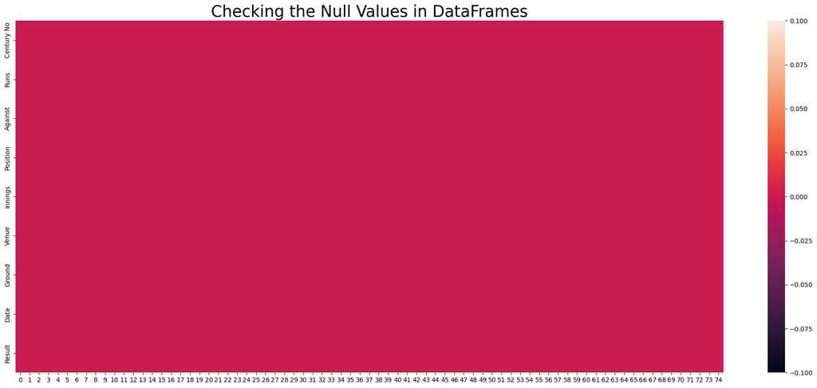

```python
plt.figure(figsize=(25,10)) # for inscrease the size of graph
plt.title('Checking the Null Values in DataFrames' , fontsize=25)

# Visualize the missing values using a heatmap
sns.heatmap(missing_values)
plt.show()
```

- There is no any Null values in datasets

# Check the info with Datatypes

```python
df.info()
```

```
<class 'pandas.core.frame.DataFrame'>
RangeIndex: 75 entries, 0 to 74
Data columns (total 9 columns):
 #   Column      Non-Null Count  Dtype
---  ------      --------------  -----
 0   Century No  75 non-null     int64
 1   Runs        75 non-null     object
 2   Against     75 non-null     object
 3   Position    75 non-null     int64
 4   Innings     75 non-null     int64
 5   Venue       75 non-null     object
 6   Ground      75 non-null     object
 7   Date        75 non-null     object
 8   Result      75 non-null     object
dtypes: int64(3), object(6)
memory usage: 5.4+ KB
```

# Focusing On:

- Need to change data type of columns 'Runs' and 'Date'

# Changing the Data Types of columns 'Runs' and 'Date'

```python
df['Date'] = pd.to_datetime(df['Date'])
```

```python
df['Runs'] = df['Runs'].str.replace("*",'')
```

```python
df['Runs'] = df['Runs'].astype(np.int64)
```

```python
df.info()
```

```
<class 'pandas.core.frame.DataFrame'>
RangeIndex: 75 entries, 0 to 74
Data columns (total 9 columns):
 #   Column      Non-Null Count  Dtype
---  ------      --------------  -----
 0   Century No  75 non-null     int64
 1   Runs        75 non-null     int64
 2   Against     75 non-null     object
 3   Position    75 non-null     int64
 4   Innings     75 non-null     int64
 5   Venue       75 non-null     object
 6   Ground      75 non-null     object
 7   Date        75 non-null     datetime64[ns]
 8   Result      75 non-null     object
dtypes: datetime64[ns](1), int64(4), object(4)
memory usage: 5.4+ KB
```

# Q1: What are the countries name where Virat Kohali withwhome against made Centuries?

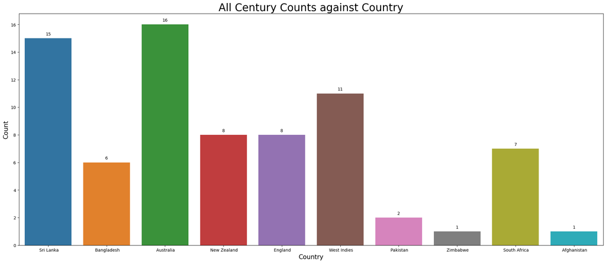

```python
plt.figure(figsize=(25, 10))  # Increase the size of the graph
plt.title('All Century Counts against Country', fontsize=25)

ax = sns.countplot(data=df, x='Against')

plt.xlabel('Country', fontsize=15)  # Set x-axis label
plt.ylabel('Count', fontsize=15)  # Set y-axis label

# Add text annotations to the bars
for p in ax.patches:
    ax.annotate(format(p.get_height(), '.0f'), (p.get_x() + p.get_width() / 2, p.get_height()), ha='center', va='center', xytext=(0, 10), textcoords='offset points')

plt.show()
```

# Result:

- Virat has made most 16 century against Austrlia in all formate
- Srilanka is the secend high with 15 century in all formate

# Q2: what are the Most Runs of Only century of Virat Kohali against Countries?

```python
againt_run = df.groupby('Against')['Runs'].sum()
againt_run
```

```
Against
 Afghanistan      122
 Australia       2003
 Bangladesh       791
 England         1098
 New Zealand     1035
 Pakistan         290
 South Africa    1065
 Sri Lanka       2007
 West Indies     1434
 Zimbabwe         115
Name: Runs, dtype: int64
```

```
<Axes: title={'center': 'Most Runs with total of Centuries against Country'}, xlabel='---------------------------------------------------------------------------------------- Countries --------------------------------------------------------------------------------------------', ylabel='------------…
```

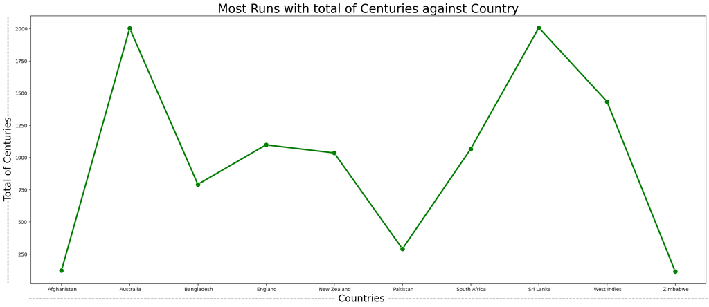

```python
plt.figure(figsize=(25, 10))  # Increase the size of the graph
plt.title('Most Runs with total of Centuries against Country', fontsize=25)
plt.xlabel('---------------------------------------------------------------------------------------- Countries --------------------------------------------------------------------------------------------',fontsize=20)
plt.ylabel('------------------------Total of Centuries-----------------------------',fontsize=20)


sns.lineplot(x=againt_run.index, y=againt_run.values, color='g', markers=True, marker='o', linewidth=3, markersize=10)
```

# Result:

- Virat has beat most of runs against Sri Lanka with 2007 runs only in century number
- and Secend one in Austrila with 2003 Runs in century number

# Q3: Best inning for Centuries?

```python
def inn(data):
    if data == 1:
        return "First Inning"
    elif data == 2:
        return "Second Inning"
    elif data == 3:
        return "Third Inning"
    elif data == 4:
        return "Forth Inning"
```

```python
df['Inning'] = df['Innings'].apply(inn)
```

```python
df.columns
```

```
Index(['Century No', 'Runs', 'Against', 'Position', 'Innings', 'Venue',
       'Ground', 'Date', 'Result', 'Inning'],
      dtype='object')
```

```python
column = list(df.columns)
new_column = column[0:5] + column[-1:] + column[5:-1]
df[new_column]
```

|  | Century No | Runs | Against | Position | Innings | Inning | Venue | Ground | Date | Result |
| --- | --- | --- | --- | --- | --- | --- | --- | --- | --- | --- |
| 0 | 1 | 107 | Sri Lanka | 4 | 2 | Second Inning | Eden Gardens, Kolkata | Home | 2009-12-24 | Won |
| 1 | 2 | 102 | Bangladesh | 3 | 2 | Second Inning | Sher-e-Bangla Cricket Stadium, Dhaka | Away | 2010-01-11 | Won |
| 2 | 3 | 118 | Australia | 3 | 2 | Second Inning | APCA-VDCA Stadium, Visakhapatnam | Home | 2010-10-20 | Won |
| 3 | 4 | 105 | New Zealand | 3 | 1 | First Inning | Nehru Stadium, Guwahati | Home | 2010-11-28 | Won |
| 4 | 5 | 100 | Bangladesh | 4 | 1 | First Inning | Sher-e-Bangla Cricket Stadium, Dhaka | Away | 2011-02-19 | Won |
| ... | ... | ... | ... | ... | ... | ... | ... | ... | ... | ... |
| 70 | 71 | 122 | Afghanistan | 2 | 1 | First Inning | Dubai International Cricket Stadium, Dubai | Neutral | 2022-09-08 | Won |
| 71 | 72 | 113 | Bangladesh | 3 | 1 | First Inning | Zohur Ahmed Chowdhury Stadium, Chittagong | Away | 2022-12-10 | Won |
| 72 | 73 | 113 | Sri Lanka | 3 | 1 | First Inning | ACA Stadium, Guwahati | Home | 2023-01-10 | Won |
| 73 | 74 | 166 | Sri Lanka | 3 | 1 | First Inning | Greenfield International Stadium, Thiruvananth... | Home | 2023-01-15 | Won |
| 74 | 75 | 186 | Australia | 4 | 2 | Second Inning | Narendra Modi Stadium, Ahmedabad | Home | 2023-03-09 | Drawn |

75 rows × 10 columns

```python
inning = df.groupby('Inning')['Runs'].count()
inning
```

```
Inning
First Inning     29
Forth Inning      2
Second Inning    41
Third Inning      3
Name: Runs, dtype: int64
```

```
<Axes: title={'center': 'Most Runs with total of Centuries in Inning'}, xlabel='---------------------------------------------------------------------------------------- Countries --------------------------------------------------------------------------------------------', ylabel='------------------…
```

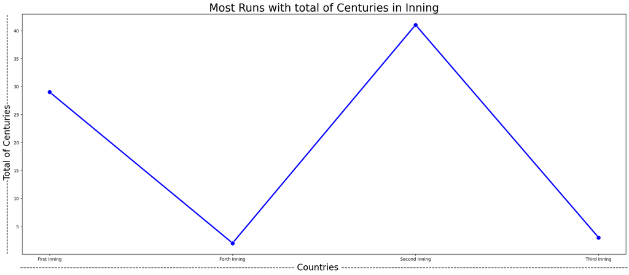

```python
plt.figure(figsize=(25, 10))  # Increase the size of the graph
plt.title('Most Runs with total of Centuries in Inning', fontsize=25)
plt.xlabel('---------------------------------------------------------------------------------------- Countries --------------------------------------------------------------------------------------------',fontsize=20)
plt.ylabel('------------------------Total of Centuries-----------------------------',fontsize=20)


sns.lineplot(x=inning.index, y=inning.values, color='b', markers=True, marker='o', linewidth=3, markersize=10)
```

# Result:

- 41 century made in second inning by Virat Kohali

# Q4: Which one are the Best ground for Virat Kohali for Century in all over the world.

```python
grouped_data = df.groupby('Ground')['Runs'].count()
grouped_data
```

```
Ground
Away       35
Home       35
Neutral     5
Name: Runs, dtype: int64
```

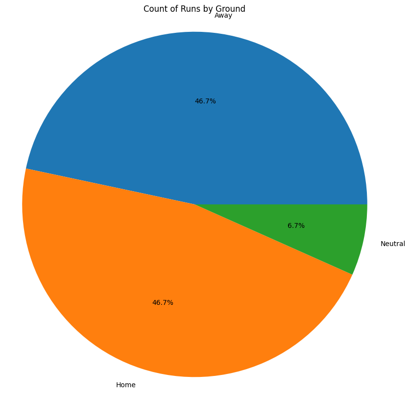

```python
plt.figure(figsize=(10, 10))  # Set the size of the pie chart
plt.title('Count of Runs by Ground')  # Set the title of the pie chart

# Create the pie chart
plt.pie(grouped_data, labels=grouped_data.index, autopct='%1.1f%%')

plt.axis('equal')  # Equal aspect ratio ensures a circular pie
plt.show()
```

# Result

- The number of century made by kohali with equal number in home or away with 35 century.

```python
vanue = df.groupby('Venue')['Runs'].count().reset_index()
vanue
```

|  | Venue | Runs |
| --- | --- | --- |
| 0 | ACA Stadium, Guwahati | 2 |
| 1 | ACA-VDCA Cricket Stadium, Visakhapatnam | 2 |
| 2 | APCA-VDCA Stadium, Visakhapatnam | 2 |
| 3 | Adelaide Oval, Adelaide | 5 |
| 4 | Basin Reserve, Wellington | 1 |
| 5 | Bellerive Oval, Hobart | 1 |
| 6 | Dubai International Cricket Stadium, Dubai | 1 |
| 7 | Eden Gardens, Kolkata | 3 |
| 8 | Edgbaston Cricket Ground, Birmingham | 1 |
| 9 | Feroz Shah Kotla Ground, Delhi | 2 |
| 10 | Galle International Stadium, Galle | 2 |
| 11 | Green Park Stadium, Kanpur | 1 |
| 12 | Greenfield International Stadium, Thiruvananth... | 1 |
| 13 | HPCA Stadium, Dharamshala | 1 |
| 14 | Harare Sports Club, Harare | 1 |
| 15 | Holkar Stadium, Indore | 1 |
| 16 | JSCA International Stadium, Ranchi | 2 |
| 17 | Khan Shaheb Osman Ali Stadium, Fatullah | 1 |
| 18 | Kingsmead Cricket Ground, Durban | 1 |
| 19 | M. A. Chidambaram Stadium, Chennai | 2 |
| 20 | M. Chinnaswamy Stadium, Bangalore | 1 |
| 21 | MRIC Stadium, Hambantota | 1 |
| 22 | Maharashtra Cricket Association Stadium, Pune | 3 |
| 23 | Manuka Oval, Canberra | 1 |
| 24 | McLean Park, Napier | 1 |
| 25 | Melbourne Cricket Ground, Melbourne | 2 |
| 26 | Narendra Modi Stadium, Ahmedabad | 1 |
| 27 | Nehru Stadium, Guwahati | 1 |
| 28 | Newlands Cricket Ground, Cape Town | 1 |
| 29 | Perth Stadium, Perth | 1 |
| 30 | Punjab Cricket Association IS Bindra Stadium, ... | 1 |
| 31 | Queen's Park Oval, Port of Spain | 3 |
| 32 | R. Premadasa Stadium, Colombo | 3 |
| 33 | Rajiv Gandhi International Cricket Stadium, Hy... | 1 |
| 34 | Sabina Park, Kingston | 1 |
| 35 | Saurashtra Cricket Association Stadium, Rajkot | 1 |
| 36 | Sawai Mansingh Stadium, Jaipur | 1 |
| 37 | Sher-e-Bangla Cricket Stadium, Dhaka | 4 |
| 38 | Sir Vivian Richards Stadium, North Sound | 1 |
| 39 | Sophia Gardens, Cardiff | 1 |
| 40 | SuperSport Park, Centurion | 2 |
| 41 | Sydney Cricket Ground, Sydney | 1 |
| 42 | Trent Bridge, Nottingham | 1 |
| 43 | VCA Stadium, Nagpur | 1 |
| 44 | Vidarbha Cricket Association Stadium, Nagpur | 3 |
| 45 | Wanderers Stadium, Johannesburg | 1 |
| 46 | Wankhede Stadium, Mumbai | 2 |
| 47 | Zohur Ahmed Chowdhury Stadium, Chittagong | 1 |

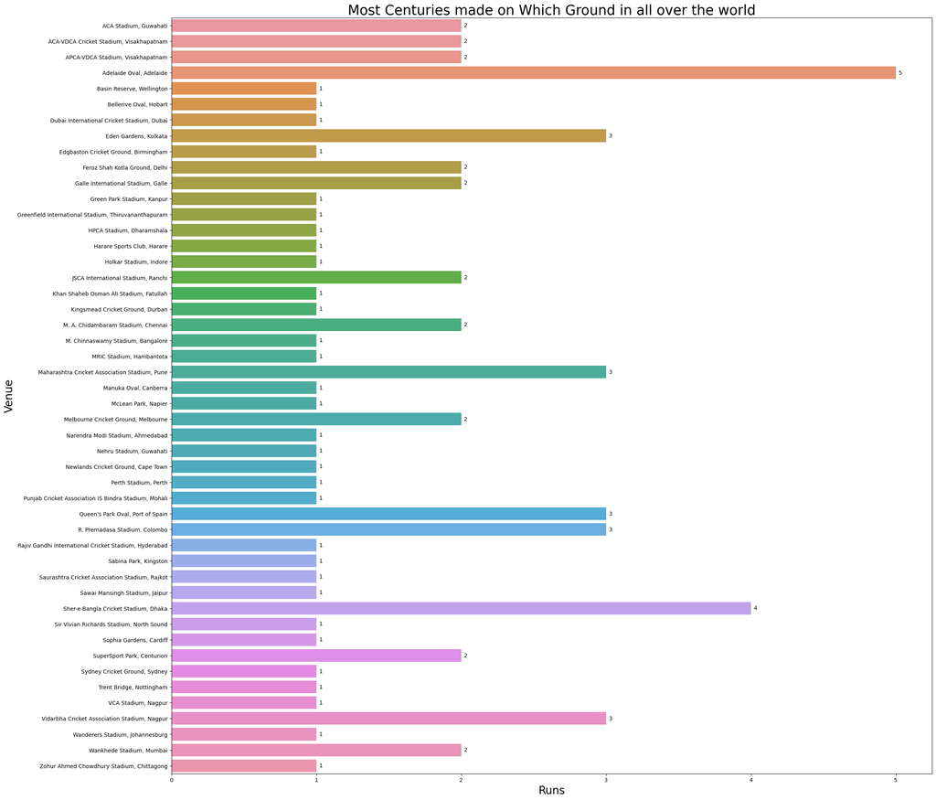

```python
plt.figure(figsize=(25, 25))  # Set the size of the bar plot
plt.title('Most Centuries made on Which Ground in all over the world', fontsize=25)  # Set the title of the bar plot
plt.xlabel('Runs', fontsize=20)  # Set x-axis label
plt.ylabel('Venue', fontsize=20)  # Set y-axis label

ax = sns.barplot(data=vanue, y='Venue', x='Runs')

# Add text annotations to the bars
for p in ax.patches:
    ax.annotate(format(p.get_width(), '.0f'), (p.get_width(), p.get_y() + p.get_height() / 2), ha='left', va='center', xytext=(5, 0), textcoords='offset points')

plt.show()
```

# Result:

- Most highest number of Century in Adelaide Oval, Adelaide in Austrlia with 5 Centuries.
- and Secend one is Sher-e-Bangla Cricket Stadium, Dhaka in Bangladesh with 4 Centuries.

# Q5: What is result of centuries number in winning or lossing cose

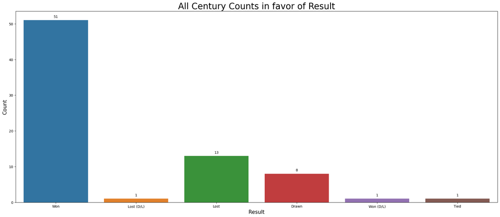

```python
plt.figure(figsize=(25, 10))  # Increase the size of the graph
plt.title('All Century Counts in favor of Result', fontsize=25)

ax = sns.countplot(data=df, x='Result')

plt.xlabel('Result', fontsize=15)  # Set x-axis label
plt.ylabel('Count', fontsize=15)  # Set y-axis label

# Add text annotations to the bars
for p in ax.patches:
    ax.annotate(format(p.get_height(), '.0f'), (p.get_x() + p.get_width() / 2, p.get_height()), ha='center', va='center', xytext=(0, 10), textcoords='offset points')

plt.show()
```

# Result:

- Virat has made 50+ centuries in winning favour

# Q6: Which year is the best for Virat for Centuries?

```python
df['Years'] = df['Date'].dt.year
```

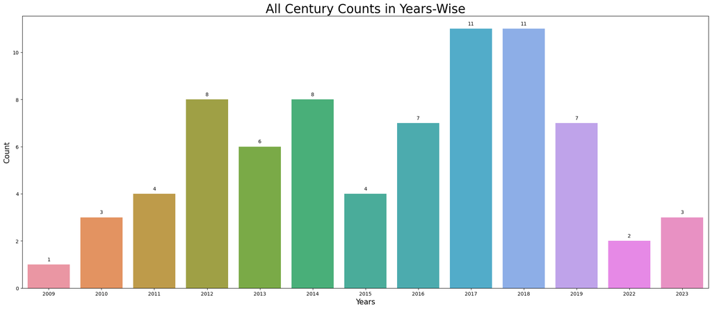

```python
plt.figure(figsize=(25, 10))  # Increase the size of the graph
plt.title('All Century Counts in Years-Wise', fontsize=25)

ax = sns.countplot(data=df, x='Years')

plt.xlabel('Years', fontsize=15)  # Set x-axis label
plt.ylabel('Count', fontsize=15)  # Set y-axis label

# Add text annotations to the bars
for p in ax.patches:
    ax.annotate(format(p.get_height(), '.0f'), (p.get_x() + p.get_width() / 2, p.get_height()), ha='center', va='center', xytext=(0, 10), textcoords='offset points')

plt.show()
```

# Result:

- for Virat Kohali's best year for centuries are 2017 and 2018 with equal number of 11.

# Q7: Total Centuries of Virat kohali

```python
print(f'Total Century of Virat Kohali is: {df.shape[0]}')
```

```
Total Century of Virat Kohali is: 75
```

# Q8: Last 5 cennturies against which countries?

```python
last5 = df.tail()
last5
```

|  | Century No | Runs | Against | Position | Innings | Venue | Ground | Date | Result | Inning | Years |
| --- | --- | --- | --- | --- | --- | --- | --- | --- | --- | --- | --- |
| 70 | 71 | 122 | Afghanistan | 2 | 1 | Dubai International Cricket Stadium, Dubai | Neutral | 2022-09-08 | Won | First Inning | 2022 |
| 71 | 72 | 113 | Bangladesh | 3 | 1 | Zohur Ahmed Chowdhury Stadium, Chittagong | Away | 2022-12-10 | Won | First Inning | 2022 |
| 72 | 73 | 113 | Sri Lanka | 3 | 1 | ACA Stadium, Guwahati | Home | 2023-01-10 | Won | First Inning | 2023 |
| 73 | 74 | 166 | Sri Lanka | 3 | 1 | Greenfield International Stadium, Thiruvananth... | Home | 2023-01-15 | Won | First Inning | 2023 |
| 74 | 75 | 186 | Australia | 4 | 2 | Narendra Modi Stadium, Ahmedabad | Home | 2023-03-09 | Drawn | Second Inning | 2023 |

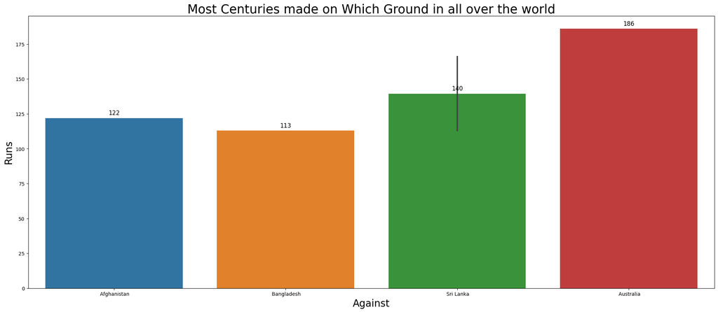

```python
plt.figure(figsize=(25, 10))  # Set the size of the bar plot
plt.title('Most Centuries made on Which Ground in all over the world', fontsize=25)  # Set the title of the bar plot
plt.xlabel('Runs', fontsize=20)  # Set x-axis label
plt.ylabel('Venue', fontsize=20)  # Set y-axis label

ax = sns.barplot(data=last5, x='Against', y='Runs')

# Set label numbers on the bars
for p in ax.patches:
    ax.annotate(format(p.get_height(), '.0f'), (p.get_x() + p.get_width() / 2., p.get_height()),
                ha = 'center', va = 'center', xytext = (0, 10), textcoords = 'offset points', fontsize=12, color='black')

plt.show()
```

# Result:

- Last 5 centuries where is 186 against Auctralia in Narendra Modi Statdium is high number.

```python
df
```

|  | Century No | Runs | Against | Position | Innings | Venue | Ground | Date | Result | Inning | Years |
| --- | --- | --- | --- | --- | --- | --- | --- | --- | --- | --- | --- |
| 0 | 1 | 107 | Sri Lanka | 4 | 2 | Eden Gardens, Kolkata | Home | 2009-12-24 | Won | Second Inning | 2009 |
| 1 | 2 | 102 | Bangladesh | 3 | 2 | Sher-e-Bangla Cricket Stadium, Dhaka | Away | 2010-01-11 | Won | Second Inning | 2010 |
| 2 | 3 | 118 | Australia | 3 | 2 | APCA-VDCA Stadium, Visakhapatnam | Home | 2010-10-20 | Won | Second Inning | 2010 |
| 3 | 4 | 105 | New Zealand | 3 | 1 | Nehru Stadium, Guwahati | Home | 2010-11-28 | Won | First Inning | 2010 |
| 4 | 5 | 100 | Bangladesh | 4 | 1 | Sher-e-Bangla Cricket Stadium, Dhaka | Away | 2011-02-19 | Won | First Inning | 2011 |
| ... | ... | ... | ... | ... | ... | ... | ... | ... | ... | ... | ... |
| 70 | 71 | 122 | Afghanistan | 2 | 1 | Dubai International Cricket Stadium, Dubai | Neutral | 2022-09-08 | Won | First Inning | 2022 |
| 71 | 72 | 113 | Bangladesh | 3 | 1 | Zohur Ahmed Chowdhury Stadium, Chittagong | Away | 2022-12-10 | Won | First Inning | 2022 |
| 72 | 73 | 113 | Sri Lanka | 3 | 1 | ACA Stadium, Guwahati | Home | 2023-01-10 | Won | First Inning | 2023 |
| 73 | 74 | 166 | Sri Lanka | 3 | 1 | Greenfield International Stadium, Thiruvananth... | Home | 2023-01-15 | Won | First Inning | 2023 |
| 74 | 75 | 186 | Australia | 4 | 2 | Narendra Modi Stadium, Ahmedabad | Home | 2023-03-09 | Drawn | Second Inning | 2023 |

75 rows × 11 columns